# BostonPCA Output

Jonathan Morris

2024-09-02

## Overview

This PCA analysis was conducted using data from https://data.boston.gov on Boston housing market data from 2024. Analysis was conducted using Principle Component Analysis from the package longpca. Longpca is an open source package developed by Karl Rohe at the University of Wisconsin-Madison. We describe methods of analysis and then highlight variables of interest.

### Let functions live here:

### Call data:

[output not shown]

#### Process data:

## Run the PCA:

```r
formula = TOTAL_VALUE ~ (YR_BUILT & ZIP_CODE)*(LIVING_AREA & BED_RMS & LAND_SF)
im = make_interaction_model(Boston, formula)
pcs2a = pca(im, k = 6)
```

### Create a pca merged data frame for mapping:

# Look at PCA plot output:

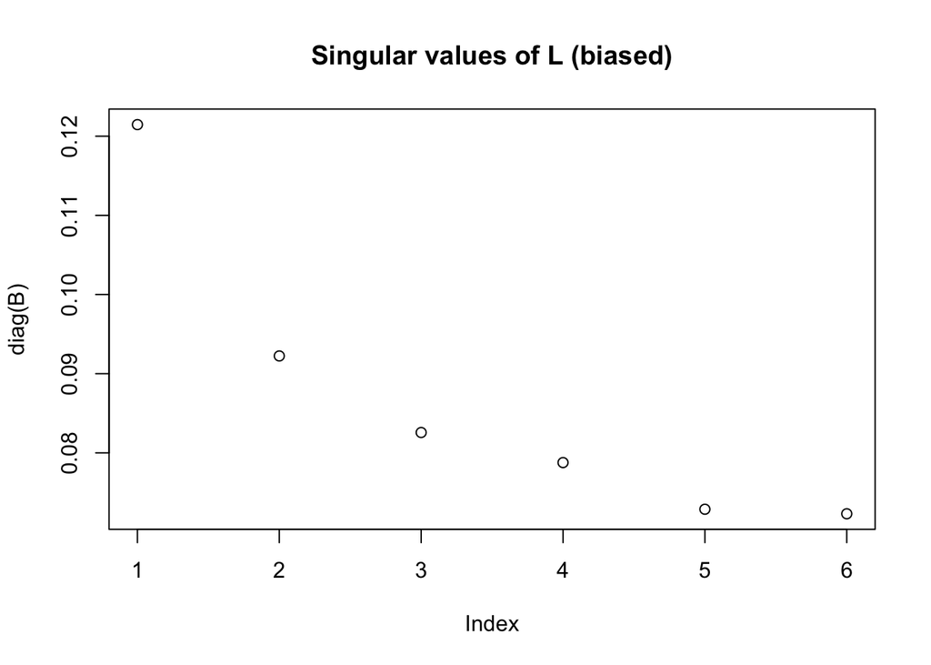

```
## Press [Enter] to continue to the next plot...
```

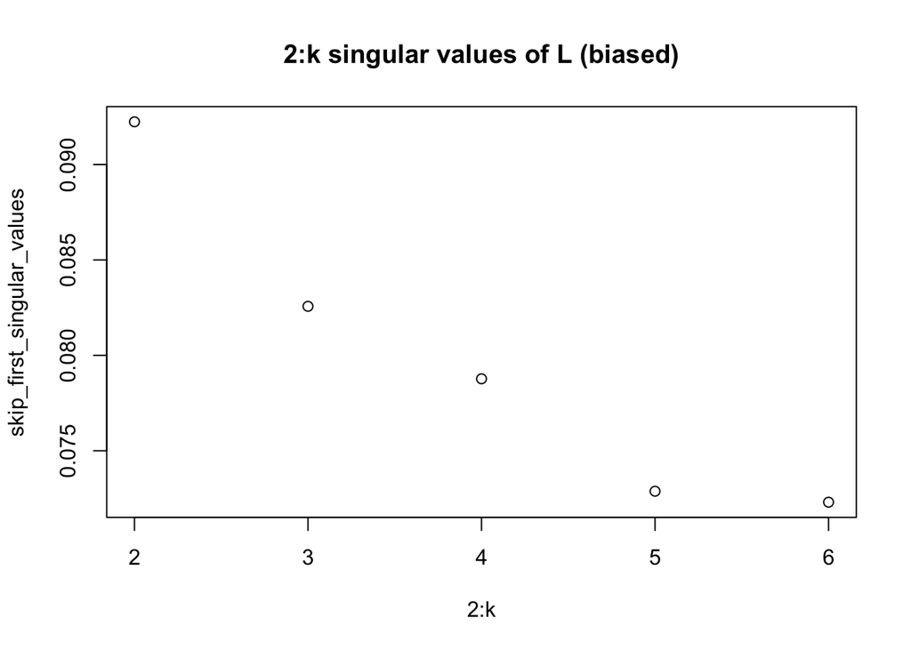

```
## Press [Enter] to continue to the next plot...
```

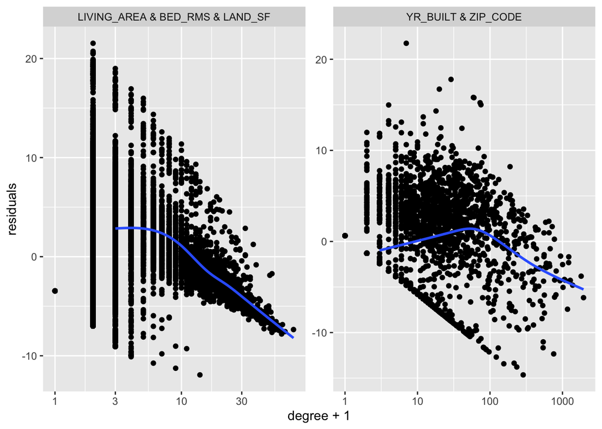

```
## Press [Enter] to continue to the next plot...
```

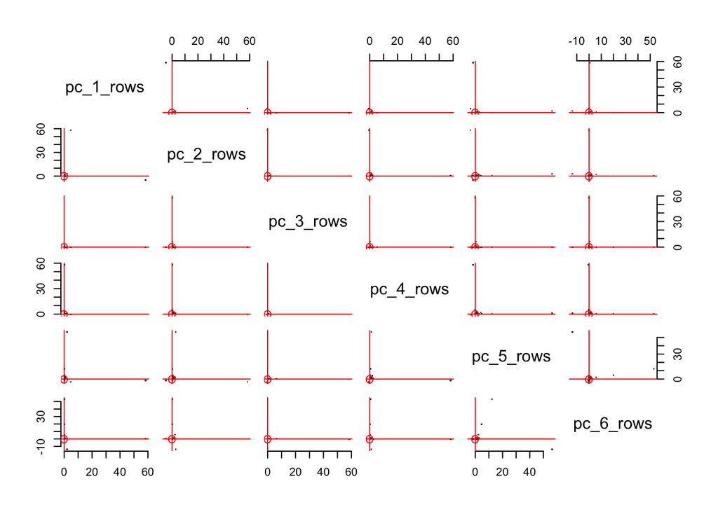

```
## Press [Enter] to continue to the next plot...
```

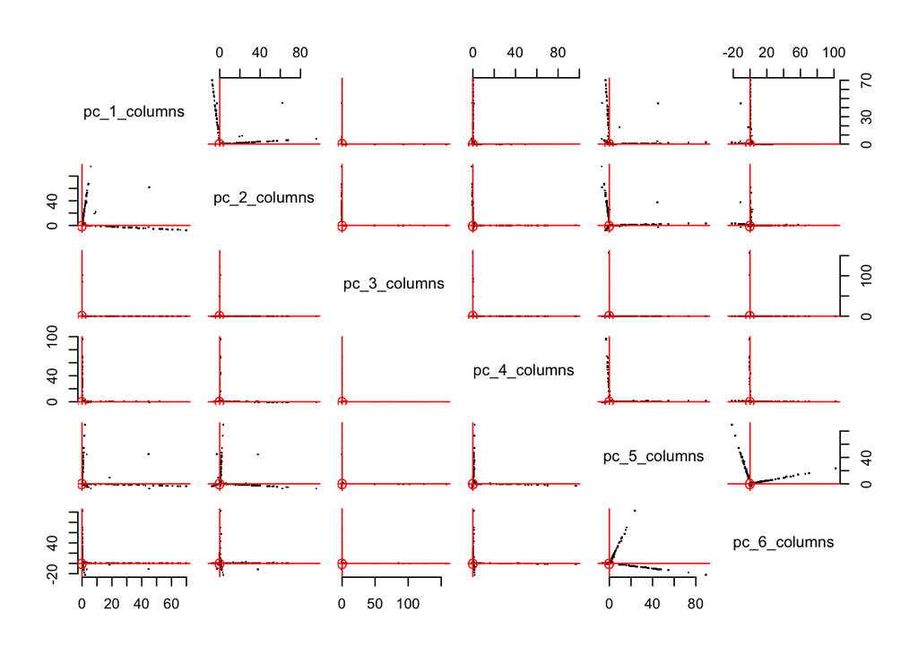

```r
plot(pcs2a)
```

## Plot data against year built:

Overall we see that housing prices increase as the house was built more recently. However, our loadings are small suggesting that date produced doesn’t excert a ton of influence on our home prices. The exception to this comes in for houses built around the late 50’s - 60’s where we see a decline in housing prices. My hypothesis is that this housing price decrease reflects the legacy of suburban growth during the same era. We saw a massive influx of suburban developments during the 60s. Many of these homes were cheaply built and put up in mass developments. Could be a possible reason we see homes built in this era with lower value.

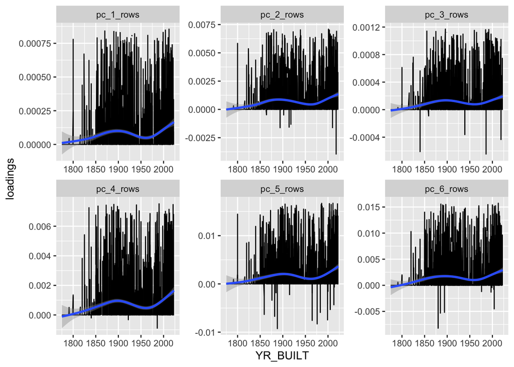

```r
PCA_Merged %>%
  select(YR_BUILT, contains("pc_")) %>%
  pivot_longer(contains("pc_"), names_to = "pc_dimension", values_to = "loadings")|>
  ggplot(aes(x = YR_BUILT, y = loadings)) + geom_line() +
  facet_wrap(~pc_dimension, scales= "free") + geom_smooth()
```

## Plot on a map:

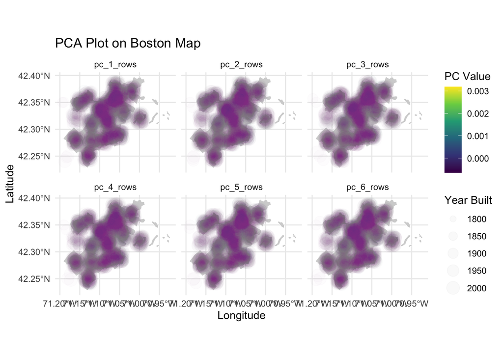

```r
#Create average loading data frame.
PCA_AVG <- PCA_Merged %>%
  group_by(ZIP_CODE) |>
  summarize(pc_1_rows = mean(pc_1_rows, na.rm = T), pc_2_rows = mean(pc_2_rows, na.rm = T), pc_3_rows = mean(pc_3_rows, na.rm = T), pc_4_rows = mean(pc_4_rows, na.rm = T), pc_5_rows = mean(pc_5_rows, na.rm = T), pc_6_rows = mean(pc_6_rows, na.rm = T), lat = mean(lat, na.rm = T), lng = mean(lng, na.rm = T), YR_BUILT = mean(YR_BUILT, na.rm = T), median_home_value = mean(median_home_value, na.rm = T), occupied_housing_units = mean(occupied_housing_units, na.rm = T))
# Create a long data frame with average loadings.
PCA_Merged_long <- PCA_AVG |>
  pivot_longer(cols = starts_with("pc_"), names_to = "PC", values_to = "value")
# Plot all 6 PC's with facet_wrap
ggplot() +
  geom_sf(data = boston_map, fill = "lightgray", color = "white") +
  geom_point(data = PCA_Merged_long, aes(x = lng, y = lat, color = value, size = YR_BUILT), alpha = 0.01) +
   geom_jitter(data = PCA_Merged, aes(x = lng, y = lat, color = pc_3_rows, size = YR_BUILT),
              width = 0.01, height = 0.01, alpha = 0.01) +
  scale_color_viridis_c(name = "PC Value") +
  scale_size_continuous(name = "Year Built") +
  coord_sf() +
  labs(title = "PCA Plot on Boston Map", x = "Longitude", y = "Latitude") +
  facet_wrap(~ PC, ncol = 3) +  # Adjust ncol to arrange the plots as desired
  theme_minimal()
```

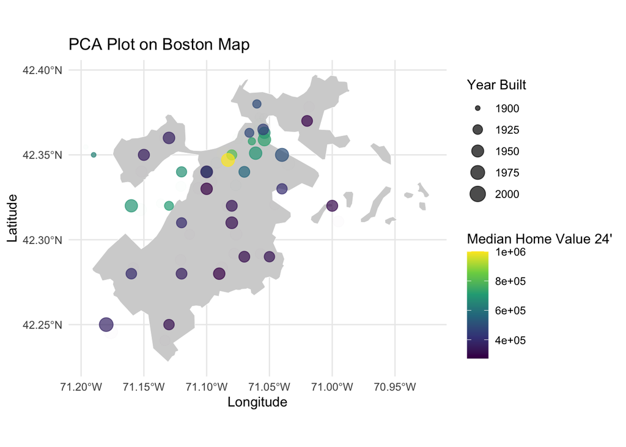

```r
ggplot() +
  geom_sf(data = boston_map, fill = "lightgray", color = "white") +
  geom_point(data = PCA_AVG, aes(x = lng, y = lat, color = median_home_value, size = YR_BUILT), alpha = 0.7) +
  geom_jitter(data = PCA_AVG, aes(x = lng, y = lat, color = median_home_value, size = YR_BUILT),
              width = 0.01, height = 0.01, alpha = 0.01) +
  scale_color_viridis_c(name = "Median Home Value 24'") +
  scale_size_continuous(name = "Year Built") +
  coord_sf() +
  labs(title = "PCA Plot on Boston Map", x = "Longitude", y = "Latitude") +
  theme_minimal()
```

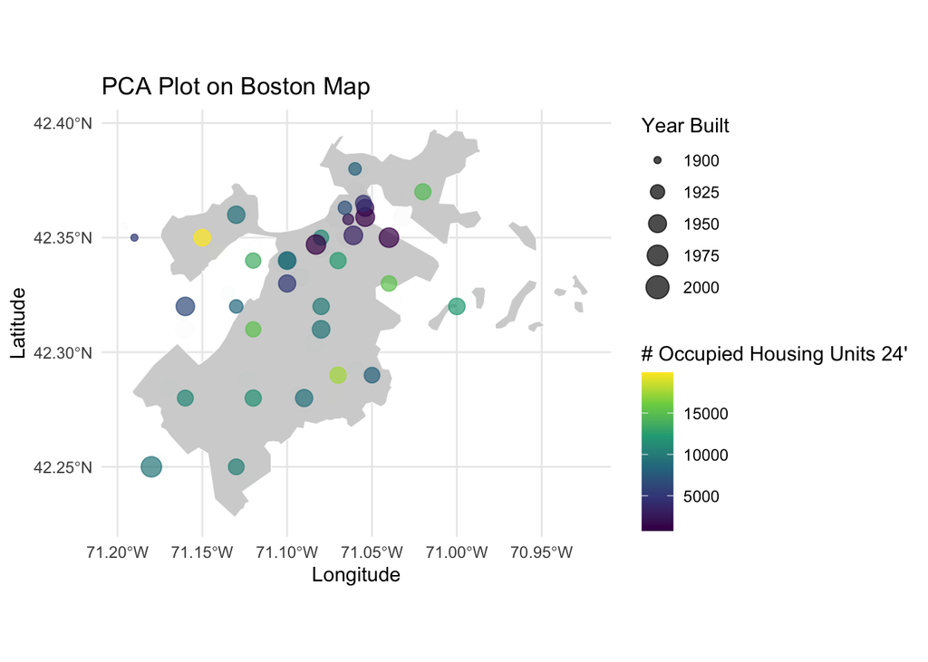

```r
ggplot() +
  geom_sf(data = boston_map, fill = "lightgray", color = "white") +
  geom_point(data = PCA_AVG, aes(x = lng, y = lat, color = occupied_housing_units , size = YR_BUILT), alpha = 0.7) +
  geom_jitter(data = PCA_AVG, aes(x = lng, y = lat, color = occupied_housing_units, size = YR_BUILT),
              width = 0.01, height = 0.01, alpha = 0.01) +
  scale_color_viridis_c(name = "# Occupied Housing Units 24'") +
  scale_size_continuous(name = "Year Built") +
  coord_sf() +
  labs(title = "PCA Plot on Boston Map", x = "Longitude", y = "Latitude") +
  theme_minimal()
```

## Now lets look at the colums. Starting with land square footage.

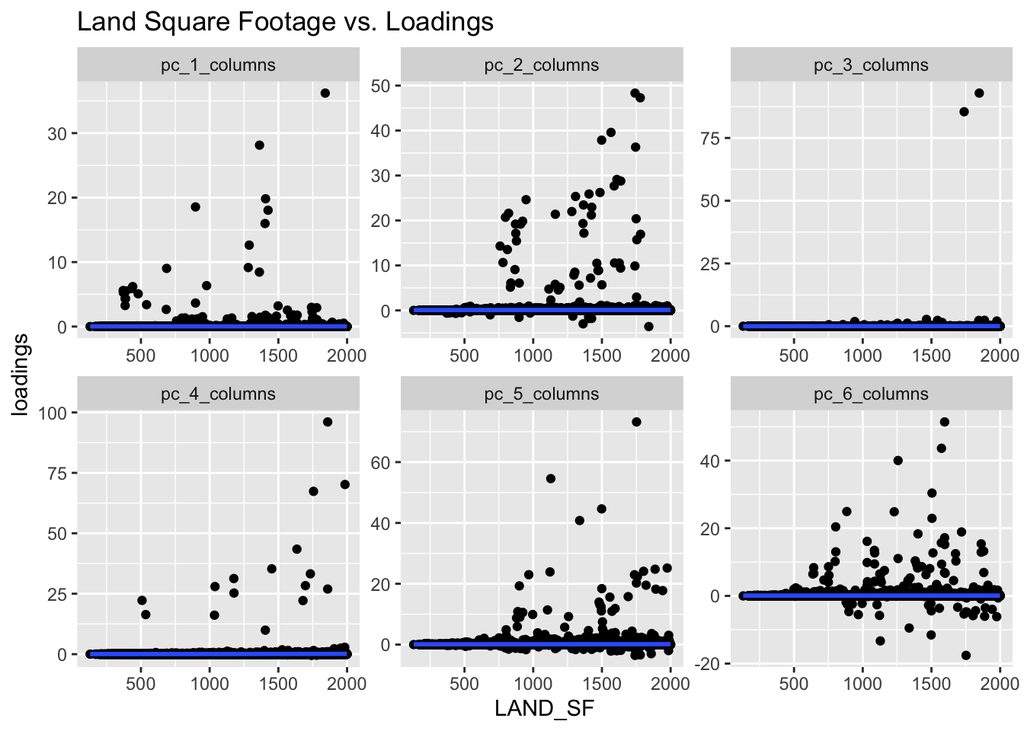

```r
PCS_Cols <- pcs2a$column_features

PCS_Cols %>%
  select(LAND_SF, contains("pc_")) %>%
  pivot_longer(contains("pc_"), names_to = "pc_dimension", values_to = "loadings")|>
  filter(LAND_SF < 2000) |>
  ggplot(aes(x = LAND_SF, y = loadings)) +
  geom_point() +
  ggtitle("Land Square Footage vs. Loadings") +
  facet_wrap(~pc_dimension, scales= "free") + geom_smooth()
```

```r
PCS_Long <- PCS_Cols %>%
  select(LAND_SF, contains("pc_")) %>%
  pivot_longer(contains("pc_"), names_to = "pc_dimension", values_to = "loadings")|>
  filter(LAND_SF < 2000)
```

## It looks almost like we see an upward trend with our data. As our square footage gets bigger, do our loadings get higher? Let’s test with a linear model.

```r
summary(lm(LAND_SF ~ loadings, PCS_Long))
```

```
##
## Call:
## lm(formula = LAND_SF ~ loadings, data = PCS_Long)
##
## Residuals:
##      Min       1Q   Median       3Q      Max
## -1142.63  -309.64    20.24   343.36   726.38
##
## Coefficients:
##             Estimate Std. Error t value Pr(>|t|)
## (Intercept) 1272.623      1.434 887.499  < 2e-16 ***
## loadings       3.767      1.298   2.902  0.00371 **
## ---
## Signif. codes:  0 '***' 0.001 '**' 0.01 '*' 0.05 '.' 0.1 ' ' 1
##
## Residual standard error: 426.5 on 88834 degrees of freedom
## Multiple R-squared:  9.478e-05,  Adjusted R-squared:  8.352e-05
## F-statistic:  8.42 on 1 and 88834 DF,  p-value: 0.003711
```

## Now let’s look at living area square footage and number of bedrooms:

[figure not shown]

```r
PCS_Cols %>%
  select(LIVING_AREA, contains("pc_")) %>%
  pivot_longer(contains("pc_"), names_to = "pc_dimension", values_to = "loadings")|>
  filter(LIVING_AREA < 2000) |> # Filter out the outliers so the plots are readable.
  ggplot(aes(x = LIVING_AREA, y = loadings)) +
  geom_point() +
  ggtitle("Living Area Square Footage vs. Loadings") +
  facet_wrap(~pc_dimension, scales= "free") + geom_smooth()
```

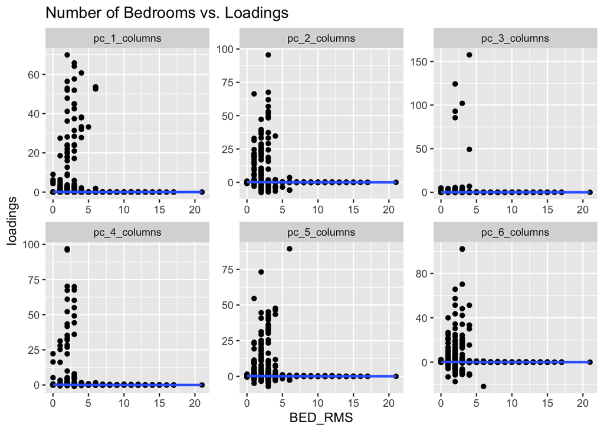

```r
PCS_Cols %>%
  select(BED_RMS, contains("pc_")) %>%
  pivot_longer(contains("pc_"), names_to = "pc_dimension", values_to = "loadings")|>
  filter(BED_RMS < 2000) |> # Filter out the outliers so the plots are readable.
  ggplot(aes(x = BED_RMS, y = loadings)) +
  geom_point() +
  ggtitle("Number of Bedrooms vs. Loadings") +
  facet_wrap(~pc_dimension, scales= "free") + geom_smooth()
```

We see the same trend from land square footage for living area square footage. However, we see that the houses with lower numbers of bedrooms have much higher loadings. Could be due to the fact that only a small number of houses have more than five bedrooms. Overall, this suggests that houses with 5 for less bedrooms contribute significantly to the variance seen in our data. This makes sense as Boston is an older American city, so land value is especially high. There is a lot of variance in the price of houses based on bedrooms because high priced houses may be costly for factors like location, and may often have limited space.

# Overall Interpretation:

Recall our model once more: formula = TOTAL_VALUE ~ (YR_BUILT & ZIP_CODE)*(LIVING_AREA & BED_RMS & LAND_SF).

It seems as though the year the home was built and zip code provide interesting and informative predictions toward the total value of the home. We see that more recent homes are often worth more. There is also an interesting period in the 50s - 60s where homes produced in that era are now worth less. Overall we see differences in price based on zip code. It’s clear that our model picked up on variability in home prices based on neighborhoods where homes are more valuable. However, since Boston is a pretty expensive city, and our PCA only looked at zip code, our model suggests that there isn’t a ton of variability in home price based on zip code. I am sure this would change if we looked somewhere else or used neighborhood as a term instead of zip code.

Overall, a successful method for uncovering which variables are most important here. If I were analyzing this data further I’d look into how differences in the size of a home interact with location and avg number of residents to predict home price. I’d also like to look at these trends over time to see how housing prices have fluctuated over the past 10 years.